# ATLAS DE TÉCNICAS DE ARTES TEXTILES EN ORIGINAL

Registros obtenidos - Tijuana

## Técnicas

### Técnicas por estado

Este mapa muestra el número de técnicas registradas por estado; los tonos más oscuros indican mayor cantidad de técnicas. Pasa el cursor para ver el nombre del estado y su conteo.

[interactive chart not shown]

### Cantidad de técnicas registradas por estado

Ranking de estados con más técnicas distintas reportadas. Las etiquetas indican el total de técnicas por estado.

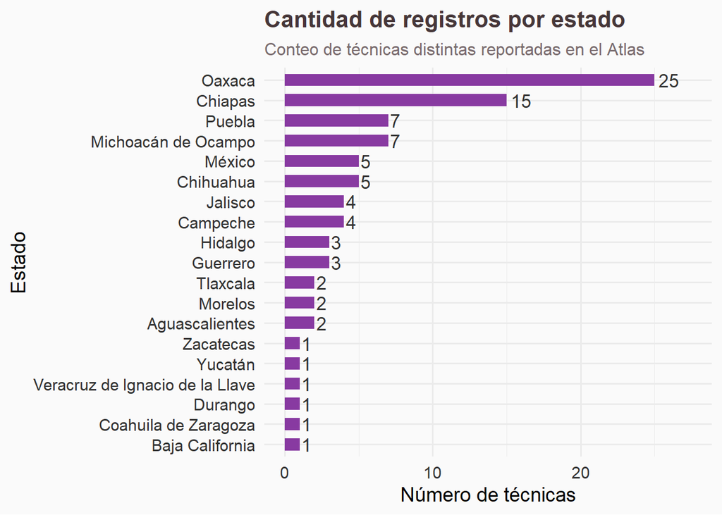

### Relación entre estados y técnicas

Flujos entre los 5 estados con más técnicas y las 10 técnicas más frecuentes. El ancho de cada flujo corresponde al número de registros compartidos.

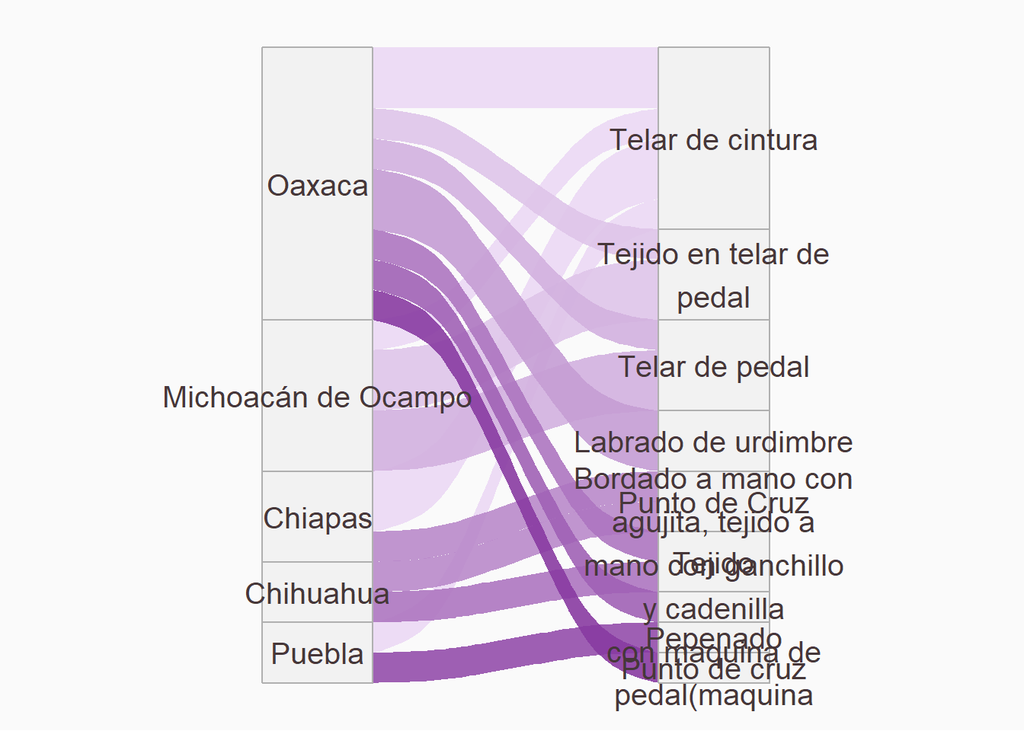

### Técnicas más comúnes

Para cada estado se presenta la técnica con mayor número de personas únicas que la reportan, ordenada por relevancia

| Estado | Técnica más común | Personas únicas |
| --- | --- | --- |
| Campeche | Punto de cruz | 3 |
| Chiapas | Telar de cintura | 2 |
| Guerrero | Bordado de chaquira | 2 |
| Oaxaca | Labrado de urdimbre | 2 |
| Aguascalientes | Filigrana y calados | 1 |
| Baja California | Trensilla | 1 |
| Chihuahua | Costura aplicada sobre tela | 1 |
| Coahuila de Zaragoza | Telar de pedales | 1 |
| Durango | Bordado en punta en cruz | 1 |
| Hidalgo | Hilvan | 1 |

[output cut: 9 more lines]

## Características de la técnica

### Distribución general de manufactura (por técnica)

Participación porcentual de los tipos de manufactura (de mayor a menor). Las etiquetas muestran el porcentaje sobre el total.

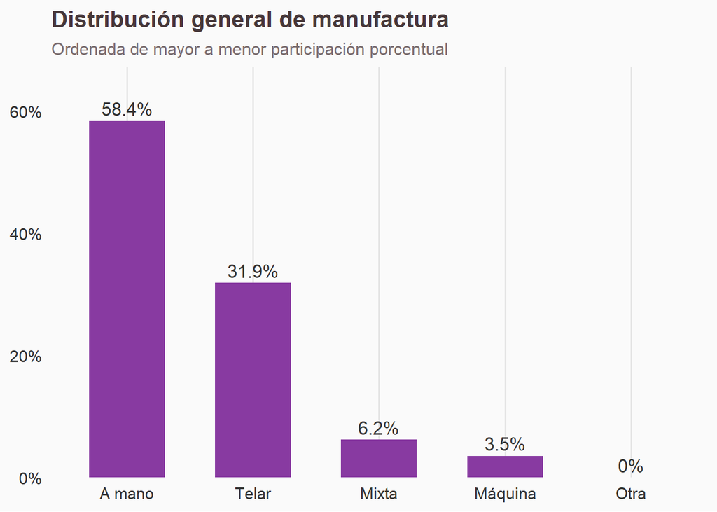

### Tipos de manufactura por estado

Composición relativa de los tipos de manufactura en cada estado. Permite comparar proporciones internas más que volúmenes absolutos.

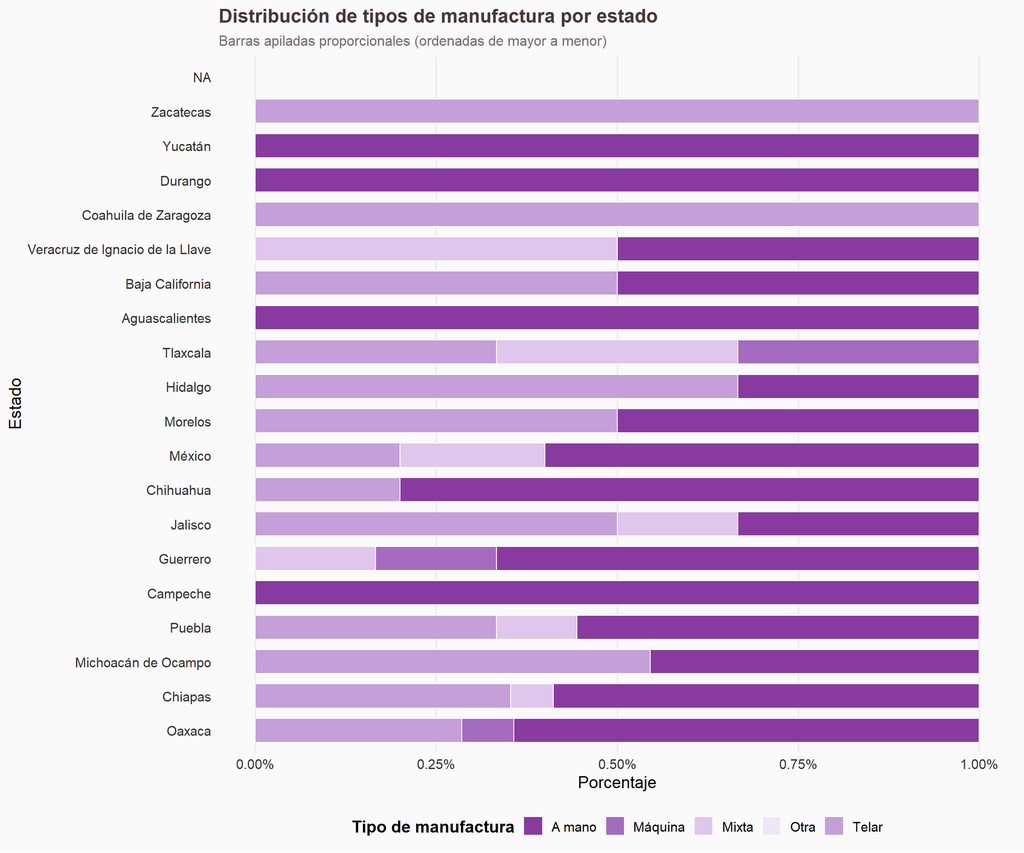

### Materiales

Los rectángulos representan los materiales más mencionados; su tamaño es proporcional a la frecuencia y la etiqueta incluye el porcentaje.

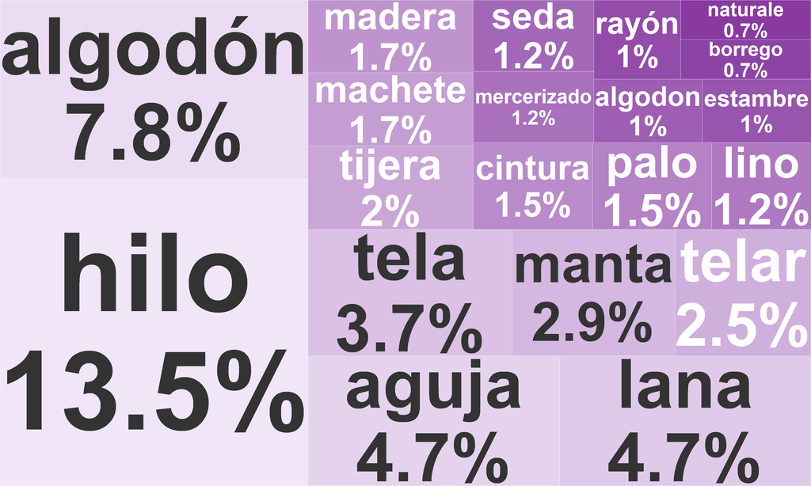

### Distribución general por tipo teñido

Participación porcentual de los tipos de teñido empleados, ordenados de mayor a menor.

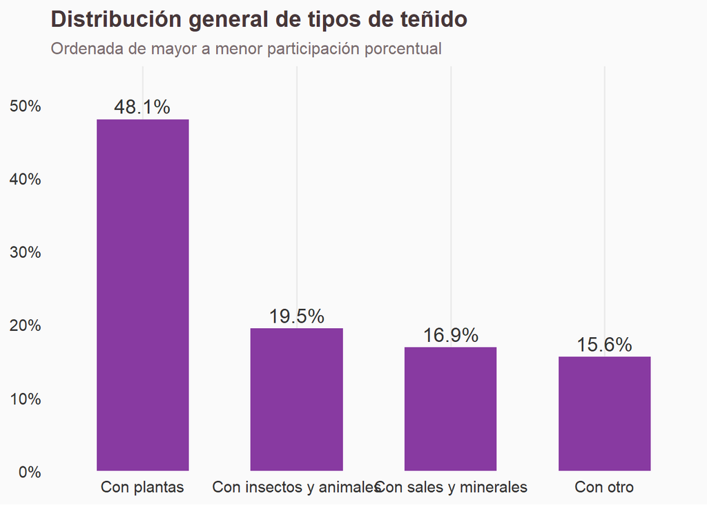

## Transmisión

### Aprendizaje

Distribución de las fuentes de aprendizaje reportadas. Los porcentajes se calculan sobre el total de respuestas.

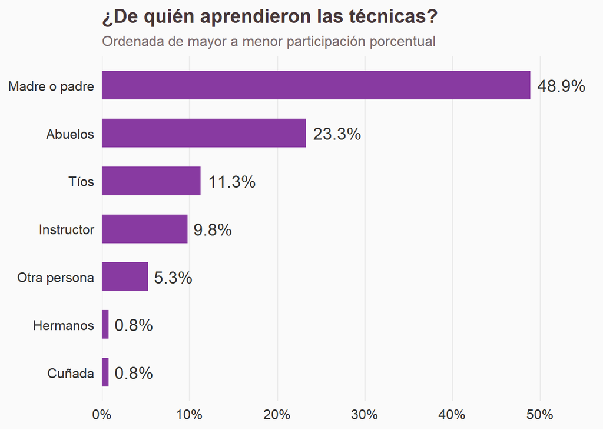

### Enseñanza

Destinatarios a quienes se transmite la técnica. Los porcentajes se calculan sobre el total de respuestas.

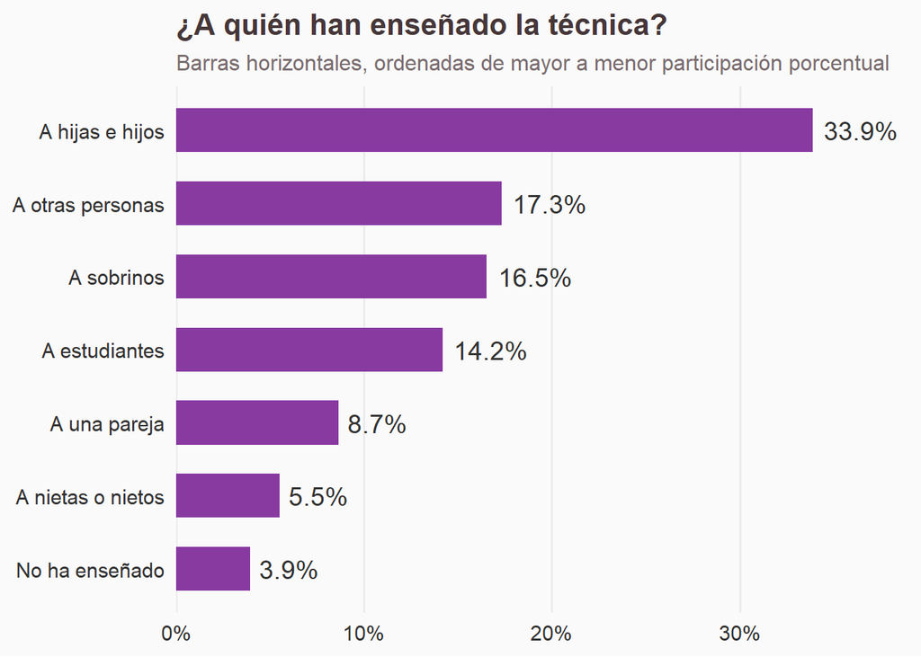

### Cadena de transmisión de saberes

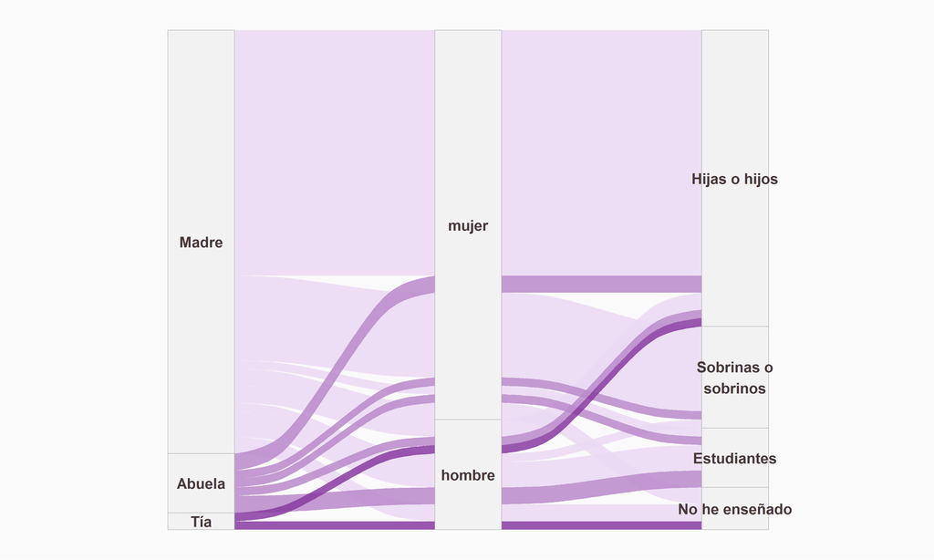

## Prendas

### Productos más frecuentes

Top de productos mencionados; el tamaño del recuadro refleja su frecuencia y la etiqueta muestra el porcentaje.

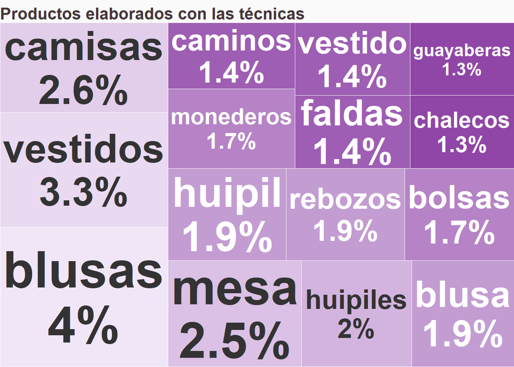

## Ceremonias

### Ceremonias asociadas a las técnicas

Top de ceremonias mencionadas; el tamaño del recuadro refleja su frecuencia y la etiqueta muestra el porcentaje.

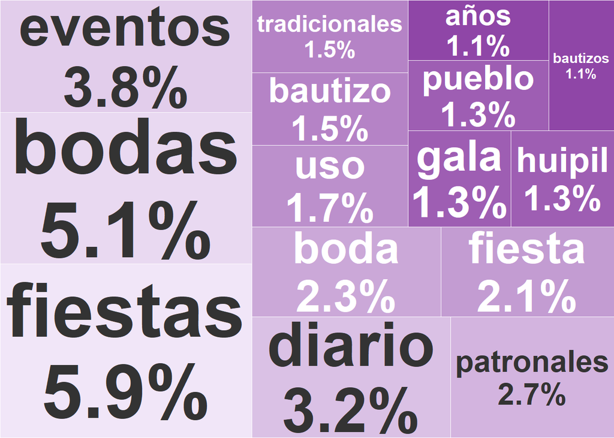